# Projeto de Introdução à Ciência de Dados UERJ

Mauricio Araujo e Bruno Oliveira

08 02 2021

# 1 **Descrição da Base de Dados**

CartolaFC é o jogo futebol fantasy mais popular do Brasil. Antes de cada rodada da Liga Brasileira de Futebol, os jogadores escolhem os atletas que desejam para seus times e marcam pontos com base em seu desempenho na vida real. Com a nossa base da dados, no ano de 2016, teremos acesso às pontuações de cada jogador a cada rodada junto de vários atributos que podemos usar na nossa análise.

## 1.1 **Fonte dos dados**

Kaggle: https://www.kaggle.com/schiller/cartolafc.

Github: https://github.com/henriquepgomide/caRtola.

## 1.2 **Dicionário de dados**

Os dados são divididos em 7 tipos de arquivos referidos ao campeonato de 2016 onde nos transformaremos esses dados em dataframes (tabelas onde podemos manipular esses dados):

**Posições**

- ID: ID da posição
- Nome: Nome da posição
- Abreviacao: Abreviação da posição

```r
posicao %>%
  kbl() %>%
  kable_styling()
```

| id | nome | abreviacao |
| --- | --- | --- |
| 1 | Goleiro | gol |
| 2 | Lateral | lat |
| 3 | Zagueiro | zag |
| 4 | Meia | mei |
| 5 | Atacante | ata |
| 6 | Técnico | tec |

**Status**

- ID: ID do status
- Nome: Nome do status

```r
status %>%
  kbl() %>%
  kable_styling()
```

| id | nome |
| --- | --- |
| 2 | Dúvida |
| 3 | Suspenso |
| 5 | Contundido |
| 6 | Nulo |
| 7 | Provável |

**Clubes**

- ID: ID do clube
- Nome: Nome do clube
- Abreviacao: Abreviação do clube
- Slug: Slug do clube

```r
head(clubes)%>%
  kbl() %>%
  kable_styling()
```

| id | nome | abreviacao | slug |
| --- | --- | --- | --- |
| 262 | Flamengo | FLA | Flamengo |
| 263 | Botafogo | BOT | Botafogo |
| 264 | Corinthians | COR | Corinthians |
| 266 | Fluminense | FLU | Fluminense |
| 275 | Palmeiras | PAL | Palmeiras |
| 276 | São Paulo | SAO | Sao-Paulo |

**Partidas**

- ID: Id da partida
- Rodada: Rodada em que a partida ocorreu
- Clube_Casa_ID: ID do clube mandante
- Clube_Visitante_ID: ID do clube visitante
- Placar_oficial_mandante: Placar do clube mandante
- Placar_oficial_visitante: Placar do clube visitante

```r
head(partidas)%>%
  kbl() %>%
  kable_styling()
```

| id | rodada | clube_casa_id | clube_visitante_id | placar_oficial_mandante | placar_oficial_visitante |
| --- | --- | --- | --- | --- | --- |
| 201226 | 1 | 262 | 292 | 1 | 0 |
| 201227 | 1 | 263 | 276 | 0 | 1 |
| 201228 | 1 | 264 | 284 | 0 | 0 |
| 201229 | 1 | 275 | 293 | 4 | 0 |
| 201234 | 1 | 282 | 277 | 1 | 0 |
| 201230 | 1 | 285 | 315 | 0 | 0 |

**Atletas**

- ID: ID do atleta
- Apelido: Apelido do atleta
- ClubeID: ID do clube do atleta
- PosicaoID: ID da posição do atleta

```r
head(atletas)%>%
  kbl() %>%
  kable_styling()
```

| id | apelido | clube_id | posicao_id |
| --- | --- | --- | --- |
| 89258 | Daniel | 262 | 1 |
| 68873 | Paulo Victor | 262 | 1 |
| 79066 | Alex Muralha | 262 | 1 |
| 91194 | Thiago | 262 | 1 |
| 38109 | Jefferson | 263 | 1 |
| 70222 | Sidão | 263 | 1 |

**Scouts**

- Atleta_ID: ID do atleta
- Rodada: Rodada em que o scout ocorreu
- Clube_ID: ID do clube do atleta
- Participou: Indica se o jogador participou da rodada
- Pontos_num: Pontuação do atleta nesta rodada
- Media_num: Média de pontos do atleta até está rodada (inclue rodada atual)
- Preco_num: Preço do atleta nesta rodada
- Variacao_num: Variação do preço da rodada passada para atual
- FS: Faltas sofridas
- PE: Passes errados
- A: Assistências
- FT: Finalizações na trave
- FD: Finalizações defendidas
- FF: Finalizações para fora
- G: Gols
- I: Impedimentos
- PP: Penaltis perdidos
- RB: Roubadas de bola
- FC: Faltas cometidas
- GC: Gols contras
- CA: Cartões Amarelos
- CV: Cartões Vermelhos
- SG: Jogo sem sofrer gols
- DD: Defesas dificeis
- DP: Defesa de penaltis
- GS: Gols sofridos

```r
head(scouts)%>%
  kbl() %>%
  kable_styling()
```

| atleta_id | rodada | clube_id | participou | pontos_num | media_num | preco_num | variacao_num | FS | PE | A | FT | FD | FF | G | I | PP | RB | FC | GC | CA | CV | SG | DD | DP | GS |
| --- | --- | --- | --- | --- | --- | --- | --- | --- | --- | --- | --- | --- | --- | --- | --- | --- | --- | --- | --- | --- | --- | --- | --- | --- | --- |
| 50301 | 0 | 262 | FALSE | 0 | 0 | 13 | 0 | 0 | 0 | 0 | 0 | 0 | 0 | 0 | 0 | 0 | 0 | 0 | 0 | 0 | 0 | 0 | 0 | 0 | 0 |
| 36540 | 0 | 262 | FALSE | 0 | 0 | 7 | 0 | 0 | 0 | 0 | 0 | 0 | 0 | 0 | 0 | 0 | 0 | 0 | 0 | 0 | 0 | 0 | 0 | 0 | 0 |
| 68685 | 0 | 262 | FALSE | 0 | 0 | 10 | 0 | 0 | 0 | 0 | 0 | 0 | 0 | 0 | 0 | 0 | 0 | 0 | 0 | 0 | 0 | 0 | 0 | 0 | 0 |
| 68711 | 0 | 262 | FALSE | 0 | 0 | 3 | 0 | 0 | 0 | 0 | 0 | 0 | 0 | 0 | 0 | 0 | 0 | 0 | 0 | 0 | 0 | 0 | 0 | 0 | 0 |
| 88065 | 0 | 262 | FALSE | 0 | 0 | 15 | 0 | 0 | 0 | 0 | 0 | 0 | 0 | 0 | 0 | 0 | 0 | 0 | 0 | 0 | 0 | 0 | 0 | 0 | 0 |
| 89258 | 0 | 262 | FALSE | 0 | 0 | 2 | 0 | 0 | 0 | 0 | 0 | 0 | 0 | 0 | 0 | 0 | 0 | 0 | 0 | 0 | 0 | 0 | 0 | 0 | 0 |

**Pontuação**

- “abreviacao”: abreviação,
- “nome”: nome,
- “pontuacao”: pontos ganhos para a respectiva ação

```r
pontuacao%>%
  kbl() %>%
  kable_styling()
```

| abreviacao | nome | pontuacao |
| --- | --- | --- |
| RB | Roubada de bola | 1.7 |
| FC | Falta cometida | -0.5 |
| GC | Gol contra | -6.0 |
| CA | Cartão amarelo | -2.0 |
| CV | Cartão vermelho | -5.0 |
| SG | Jogo sem sofrer gol | 5.0 |
| DD | Defesa difícil | 3.0 |
| DP | Defesa de pênalti | 7.0 |
| GS | Gol sofrido | -2.0 |
| FS | Falta sofrida | 0.5 |
| PE | Passe errado | -0.3 |
| A | Assistência | 5.0 |
| FT | Finalização na trave | 3.5 |
| FD | Finalização defendida | 1.0 |
| FF | Finalização para fora | 0.7 |
| G | Gol | 8.0 |
| I | Impedimento | -0.5 |
| PP | Pênalti perdido | -3.5 |

# 2 **Preparação dos Dados**

## 2.1 **Questões a serem respondidas**

Com a nossa base de dados, buscaremos entender quais estratégias funcionam melhor para termos a probabilidade de somar o maior número de pontos no jogo, de acordo com a pontuação dos jogadores e suas determinadas características.

Assim poderemos responder as seguintes questões:

- Quais clubes tem jogadores com mais pontos em média?
- Qual melhor formação?
- Times que jogam em casa pontuam mais?
- Vale mais a pena escalar meias defensivos ou ofensivos?

Obs: Deixando claro que nossas análises serão baseadas em estatística do campeonato em questão de maneira geral e que, obviamente, não constitui a melhor estratégia já que ela pode ser superada por análises mais aprofundadas por quem conhece melhor a situação dos jogadores e clubes em determinadas rodadas separadamente.

## 2.2 **Tratamento dos Dados**

Usamos a função `str()` para analisar todos 7 arquivos de dados e os tipos de seus campos concluindo que todos já estavam corretos.

```r
str(clubes) #Ok
```

```
## tibble [20 x 4] (S3: spec_tbl_df/tbl_df/tbl/data.frame)
##  $ id        : num [1:20] 262 263 264 266 275 276 277 282 283 284 ...
##  $ nome      : chr [1:20] "Flamengo" "Botafogo" "Corinthians" "Fluminense" ...
##  $ abreviacao: chr [1:20] "FLA" "BOT" "COR" "FLU" ...
##  $ slug      : chr [1:20] "Flamengo" "Botafogo" "Corinthians" "Fluminense" ...
##  - attr(*, "spec")=
##   .. cols(
##   ..   id = col_double(),
##   ..   nome = col_character(),
##   ..   abreviacao = col_character(),
##   ..   slug = col_character()
##   .. )
```

```r
str(atletas) #Ok
```

```
## tibble [1,001 x 4] (S3: spec_tbl_df/tbl_df/tbl/data.frame)
##  $ id        : num [1:1001] 89258 68873 79066 91194 38109 ...
##  $ apelido   : chr [1:1001] "Daniel" "Paulo Victor" "Alex Muralha" "Thiago" ...
##  $ clube_id  : num [1:1001] 262 262 262 262 263 263 263 263 263 263 ...
##  $ posicao_id: num [1:1001] 1 1 1 1 1 1 1 1 1 1 ...
##  - attr(*, "spec")=
##   .. cols(
##   ..   id = col_double(),
##   ..   apelido = col_character(),
##   ..   clube_id = col_double(),
##   ..   posicao_id = col_double()
##   .. )
```

```r
str(partidas) #Ok
```

```
## tibble [380 x 6] (S3: spec_tbl_df/tbl_df/tbl/data.frame)
##  $ id                      : num [1:380] 201226 201227 201228 201229 201234 ...
##  $ rodada                  : num [1:380] 1 1 1 1 1 1 1 1 1 1 ...
##  $ clube_casa_id           : num [1:380] 262 263 264 275 282 285 294 316 327 344 ...
##  $ clube_visitante_id      : num [1:380] 292 276 284 293 277 315 283 303 266 287 ...
##  $ placar_oficial_mandante : num [1:380] 1 0 0 4 1 0 1 0 0 4 ...
##  $ placar_oficial_visitante: num [1:380] 0 1 0 0 0 0 0 0 1 1 ...
##  - attr(*, "spec")=
##   .. cols(
##   ..   id = col_double(),
##   ..   rodada = col_double(),
##   ..   clube_casa_id = col_double(),
##   ..   clube_visitante_id = col_double(),
##   ..   placar_oficial_mandante = col_double(),
##   ..   placar_oficial_visitante = col_double()
##   .. )
```

```r
str(scouts) #Ok
```

```
## tibble [31,168 x 26] (S3: spec_tbl_df/tbl_df/tbl/data.frame)
##  $ atleta_id   : num [1:31168] 50301 36540 68685 68711 88065 ...
##  $ rodada      : num [1:31168] 0 0 0 0 0 0 0 0 0 0 ...
##  $ clube_id    : num [1:31168] 262 262 262 262 262 262 262 262 262 262 ...
##  $ participou  : logi [1:31168] FALSE FALSE FALSE FALSE FALSE FALSE ...
##  $ pontos_num  : num [1:31168] 0 0 0 0 0 0 0 0 0 0 ...
##  $ media_num   : num [1:31168] 0 0 0 0 0 0 0 0 0 0 ...
##  $ preco_num   : num [1:31168] 13 7 10 3 15 2 4 8 9 14 ...
##  $ variacao_num: num [1:31168] 0 0 0 0 0 0 0 0 0 0 ...
##  $ FS          : num [1:31168] 0 0 0 0 0 0 0 0 0 0 ...
##  $ PE          : num [1:31168] 0 0 0 0 0 0 0 0 0 0 ...
##  $ A           : num [1:31168] 0 0 0 0 0 0 0 0 0 0 ...
##  $ FT          : num [1:31168] 0 0 0 0 0 0 0 0 0 0 ...
##  $ FD          : num [1:31168] 0 0 0 0 0 0 0 0 0 0 ...
##  $ FF          : num [1:31168] 0 0 0 0 0 0 0 0 0 0 ...
##  $ G           : num [1:31168] 0 0 0 0 0 0 0 0 0 0 ...
##  $ I           : num [1:31168] 0 0 0 0 0 0 0 0 0 0 ...
##  $ PP          : num [1:31168] 0 0 0 0 0 0 0 0 0 0 ...
##  $ RB          : num [1:31168] 0 0 0 0 0 0 0 0 0 0 ...
##  $ FC          : num [1:31168] 0 0 0 0 0 0 0 0 0 0 ...
##  $ GC          : num [1:31168] 0 0 0 0 0 0 0 0 0 0 ...
##  $ CA          : num [1:31168] 0 0 0 0 0 0 0 0 0 0 ...
##  $ CV          : num [1:31168] 0 0 0 0 0 0 0 0 0 0 ...
##  $ SG          : num [1:31168] 0 0 0 0 0 0 0 0 0 0 ...
##  $ DD          : num [1:31168] 0 0 0 0 0 0 0 0 0 0 ...
##  $ DP          : num [1:31168] 0 0 0 0 0 0 0 0 0 0 ...
##  $ GS          : num [1:31168] 0 0 0 0 0 0 0 0 0 0 ...
##  - attr(*, "spec")=
##   .. cols(
##   ..   atleta_id = col_double(),
##   ..   rodada = col_double(),
##   ..   clube_id = col_double(),
##   ..   participou = col_logical(),
##   ..   pontos_num = col_double(),
##   ..   media_num = col_double(),
##   ..   preco_num = col_double(),
##   ..   variacao_num = col_double(),
##   ..   FS = col_double(),
##   ..   PE = col_double(),
##   ..   A = col_double(),
##   ..   FT = col_double(),
##   ..   FD = col_double(),
##   ..   FF = col_double(),
##   ..   G = col_double(),
##   ..   I = col_double(),
##   ..   PP = col_double(),
##   ..   RB = col_double(),
##   ..   FC = col_double(),
##   ..   GC = col_double(),
##   ..   CA = col_double(),
##   ..   CV = col_double(),
##   ..   SG = col_double(),
##   ..   DD = col_double(),
##   ..   DP = col_double(),
##   ..   GS = col_double()
##   .. )
```

```r
str(pontuacao) #Ok
```

```
## tibble [18 x 3] (S3: spec_tbl_df/tbl_df/tbl/data.frame)
##  $ abreviacao: chr [1:18] "RB" "FC" "GC" "CA" ...
##  $ nome      : chr [1:18] "Roubada de bola" "Falta cometida" "Gol contra" "Cartão amarelo" ...
##  $ pontuacao : num [1:18] 1.7 -0.5 -6 -2 -5 5 3 7 -2 0.5 ...
##  - attr(*, "spec")=
##   .. cols(
##   ..   abreviacao = col_character(),
##   ..   nome = col_character(),
##   ..   pontuacao = col_double()
##   .. )
```

```r
str(posicao) #Ok
```

```
## tibble [6 x 3] (S3: spec_tbl_df/tbl_df/tbl/data.frame)
##  $ id        : num [1:6] 1 2 3 4 5 6
##  $ nome      : chr [1:6] "Goleiro" "Lateral" "Zagueiro" "Meia" ...
##  $ abreviacao: chr [1:6] "gol" "lat" "zag" "mei" ...
##  - attr(*, "spec")=
##   .. cols(
##   ..   id = col_double(),
##   ..   nome = col_character(),
##   ..   abreviacao = col_character()
##   .. )
```

```r
str(status)  #Ok
```

```
## tibble [5 x 2] (S3: spec_tbl_df/tbl_df/tbl/data.frame)
##  $ id  : num [1:5] 2 3 5 6 7
##  $ nome: chr [1:5] "Dúvida" "Suspenso" "Contundido" "Nulo" ...
##  - attr(*, "spec")=
##   .. cols(
##   ..   id = col_double(),
##   ..   nome = col_character()
##   .. )
```

Usamos a função `is.na()` para também analisar os dados ausentes dos arquivos e tratá-los se necessário.

```r
TRUE %in% is.na(clubes) #Ok
```

```
## [1] FALSE
```

```r
TRUE %in% is.na(atletas) #Ok
```

```
## [1] FALSE
```

```r
TRUE %in% is.na(partidas) #Não Ok
```

```
## [1] TRUE
```

```r
sum(is.na(partidas))/length(partidas[[1]]) #Porcentagem insignificante dos dados
```

```
## [1] 0.005263158
```

```r
TRUE %in% is.na(scouts) #Não Ok
```

```
## [1] TRUE
```

```r
sum(is.na(scouts))/length(scouts[[1]]) #Porcentagem insignificante dos dados
```

```
## [1] 0.0002245893
```

```r
TRUE %in% is.na(pontuacao) #Ok
```

```
## [1] FALSE
```

```r
TRUE %in% is.na(posicao) #Ok
```

```
## [1] FALSE
```

```r
TRUE %in% is.na(status)  #Ok
```

```
## [1] FALSE
```

Vimos que apenas duas tabelas continham alguns dados ausentes que, felizmente, não prejudicam nossa análise já que se trata de uma parcela insignificante das mesmas.

Porém, vimos que nos dados `atletas`, usando o `summary()`, a `posicao_id` dos atletas não estava sendo tratada como fator, assim, consultando o dataset `posicao`, achamos mais conveniente alterar para facilitar o tratamento dos dados mais a frente.

```r
  summary(atletas)
```

```
  ##        id          apelido             clube_id       posicao_id
  ##  Min.   :36540   Length:1001        Min.   :262.0   Min.   :1.0
  ##  1st Qu.:68925   Class :character   1st Qu.:276.0   1st Qu.:3.0
  ##  Median :80583   Mode  :character   Median :285.0   Median :4.0
  ##  Mean   :76280                      Mean   :290.3   Mean   :3.6
  ##  3rd Qu.:90637                      3rd Qu.:303.0   3rd Qu.:5.0
  ##  Max.   :97460                      Max.   :344.0   Max.   :6.0
```

```r
  atletas$posicao_id <- factor(atletas$posicao_id,
                             levels = c(1:6),
                             labels = c("goleiro", "lateral", "zagueiro",
                                        "meia", "atacante", "tecnico"))

  summary(atletas)
```

```
  ##        id          apelido             clube_id        posicao_id
  ##  Min.   :36540   Length:1001        Min.   :262.0   goleiro : 97
  ##  1st Qu.:68925   Class :character   1st Qu.:276.0   lateral :139
  ##  Median :80583   Mode  :character   Median :285.0   zagueiro:152
  ##  Mean   :76280                      Mean   :290.3   meia    :339
  ##  3rd Qu.:90637                      3rd Qu.:303.0   atacante:227
  ##  Max.   :97460                      Max.   :344.0   tecnico : 47
```

Obs: Algumas outras variáveis dos dados poderiam também ter sido trocadas para fatores, porém, como são 7 arquivos e não usamos tais variáveis, preferimos não mudá-las.

# 3 **Análise Exploratória**

Recapitulando as questões que iríamos tentar responder:

## 3.1 **Quais clubes tem jogadores com mais pontos em média?**

Para responder essa questão, filtramos apenas os jogadores que jogaram na tabela `scouts`, a partir da primeira rodada e tiramos média das pontuações de cada jogador agrupada por nome do clube (que veio da tabela`clubes` após juntarmos com a tabela de `scouts`). Após isso, ordenamos do maior para o menor. Assim, vemos que o clube com maior **média de pontos** entre seus jogadores é o Flamengo.

```r
scouts %>%
  filter(participou & rodada>=1) %>%
  inner_join(clubes, c("clube_id" = "id")) %>%
  group_by(nome) %>%
  summarise(media_pontos = mean(pontos_num), .groups = 'drop') %>%
  arrange(desc(media_pontos)) %>%
  kbl() %>%
  kable_styling()
```

| nome | media_pontos |
| --- | --- |
| Flamengo | 3.520303 |
| Santos | 3.169271 |
| Atlético-MG | 3.136102 |
| Botafogo | 3.072026 |
| Palmeiras | 2.957884 |
| São Paulo | 2.885313 |
| Grêmio | 2.877033 |
| Corinthians | 2.846383 |
| Coritiba | 2.667811 |
| Cruzeiro | 2.661279 |
| Chapecoense | 2.644240 |
| Fluminense | 2.593805 |
| Sport | 2.507618 |
| Atlético-PR | 2.434759 |
| Vitória | 2.401327 |
| Ponte Preta | 2.297996 |
| Santa Cruz | 2.164560 |
| Internacional | 2.151148 |
| Figueirense | 1.958654 |
| América-MG | 1.704714 |

Mas tem um porém, vamos analisar a tabela que diz respeito às **médias de preço** abaixo.

```r
scouts %>%
  filter(participou & rodada >= 1) %>%
  inner_join(clubes, c("clube_id" = "id")) %>%
  group_by(nome) %>%
  summarise(media_preco = mean(preco_num), .groups = 'drop') %>%
  arrange(desc(media_preco)) %>%
  kbl() %>%
  kable_styling()
```

| nome | media_preco |
| --- | --- |
| Atlético-MG | 11.058980 |
| Palmeiras | 10.132275 |
| Flamengo | 10.008274 |
| Corinthians | 9.708354 |
| Santos | 9.560107 |
| Fluminense | 8.817629 |
| Grêmio | 8.738425 |
| Internacional | 8.410848 |
| Coritiba | 8.034039 |
| Cruzeiro | 7.819805 |
| São Paulo | 7.589589 |
| Botafogo | 7.114409 |
| Sport | 7.077091 |
| Santa Cruz | 7.033626 |
| Chapecoense | 6.686773 |
| Ponte Preta | 6.508561 |
| Vitória | 6.465664 |
| Figueirense | 6.397018 |
| Atlético-PR | 5.690519 |
| América-MG | 4.461013 |

Como podemos ver, o Flamengo está entre os primeiros na média de preço fazendo com que apenas escalar jogadores de tal clube seria enviável por conta dos altos preços e dinheiro limitado no jogo. Então qual clube teria o melhor **custo benefício**? Simples, dividimos a média de pontos pela média de preço.

```r
scouts %>%
  filter(participou & rodada >=1) %>%
  inner_join(clubes, c("clube_id" = "id")) %>%
  group_by(nome) %>%
  summarise(custo_beneficio = mean(pontos_num)/mean(preco_num), .groups = 'drop') %>%
  arrange(desc(custo_beneficio)) %>%
  kbl() %>%
  kable_styling()
```

| nome | custo_beneficio |
| --- | --- |
| Botafogo | 0.4318034 |
| Atlético-PR | 0.4278623 |
| Chapecoense | 0.3954434 |
| América-MG | 0.3821362 |
| São Paulo | 0.3801673 |
| Vitória | 0.3713969 |
| Sport | 0.3543289 |
| Ponte Preta | 0.3530729 |
| Flamengo | 0.3517392 |
| Cruzeiro | 0.3403255 |
| Coritiba | 0.3320635 |
| Santos | 0.3315099 |
| Grêmio | 0.3292393 |
| Santa Cruz | 0.3077446 |
| Figueirense | 0.3061824 |
| Fluminense | 0.2941613 |
| Corinthians | 0.2931891 |
| Palmeiras | 0.2919269 |
| Atlético-MG | 0.2835797 |
| Internacional | 0.2557588 |

Com isso, percebemos que em 2016 o clube com jogadores mais subvalorizados foi o Botafogo e com os mais sobrevalorizados foi o Internacional.

**Conclusão:** Apesar de o clube com melhor média ser o Flamengo, o dinheiro no fantasy game é limitado, assim, tornando inviável investir complemente em um clube com jogadores mais caros. Com isso, vale a pena diversificar sua escalação incluindo também jogadores baratos de outros clubes mas com bons custos benefícios.

## 3.2 **Qual melhor formação?**

Para responder essa questão, temos que olhar as pontuações por posição e decidir quais posições teremos que colocar em detrimento de outras.

- Analisando as médias, medianas, máximos e mínimos:

```r
scouts %>%
  inner_join(atletas, c("atleta_id" = "id")) %>%
  filter(participou == TRUE & rodada >=1) %>%
  group_by(posicao_id) %>%
  summarise(media = mean(pontos_num, .groups = 'drop'),
            mediana = median(pontos_num),
            max_pontos = max(pontos_num),
            min_pontos = min(pontos_num), .groups = 'drop') %>%
  kbl() %>%
  kable_styling()
```

| posicao_id | media | mediana | max_pontos | min_pontos |
| --- | --- | --- | --- | --- |
| goleiro | 3.171616 | 3.500 | 21.00 | -10.50 |
| lateral | 3.212148 | 2.900 | 21.70 | -9.70 |
| zagueiro | 2.540412 | 2.100 | 23.50 | -11.20 |
| meia | 2.216188 | 1.300 | 27.60 | -7.80 |
| atacante | 2.623253 | 1.100 | 28.20 | -6.60 |
| tecnico | 3.262986 | 3.035 | 10.54 | -1.62 |

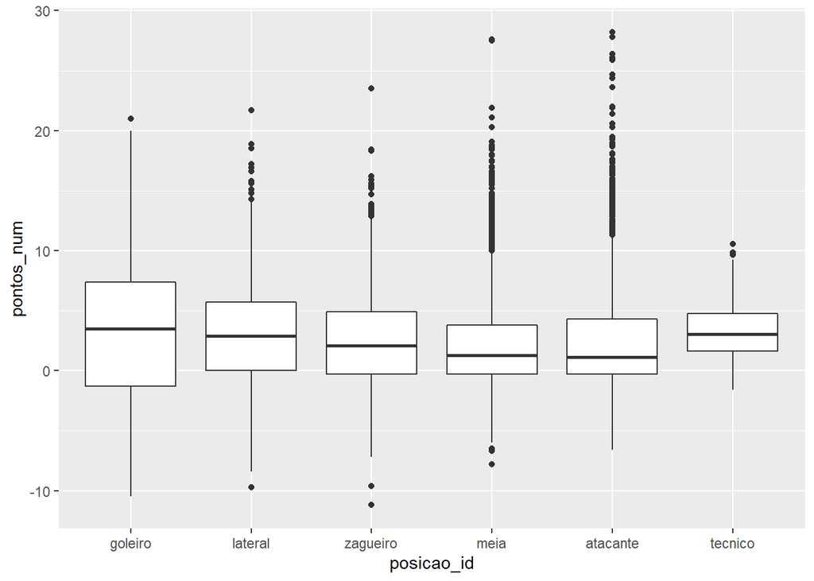

```r
scouts %>%
  inner_join(atletas, c("atleta_id" = "id")) %>%
  filter(participou == TRUE & rodada>=1) %>%
  group_by(posicao_id) %>%
  ggplot(aes(posicao_id,pontos_num)) +
  geom_boxplot()
```

Analisando o **custo benefício** das posições (pontos por preço) entre os jogadores com um histórico razoável(`media_num` > 6 pontos) a partir da quinta rodada, já que a média de pontos ainda não é bem estabelecida nas primeiras rodadas:

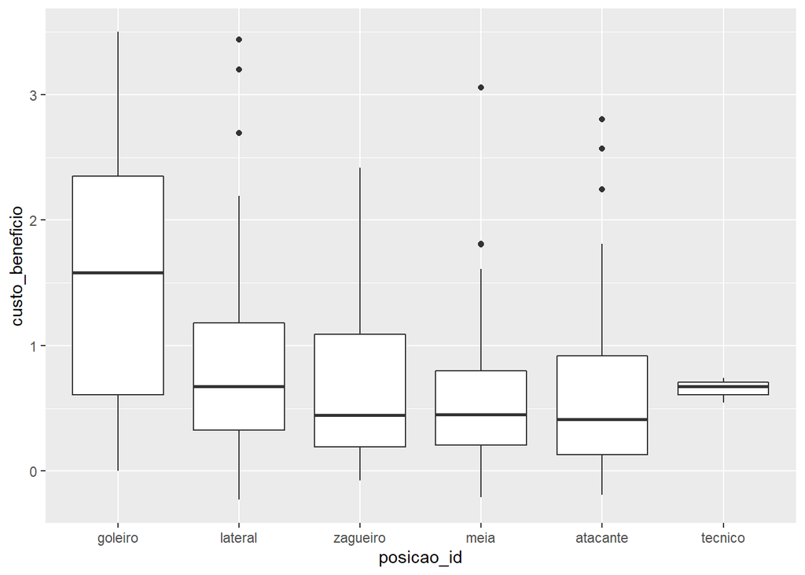

```r
scouts %>%
  inner_join(atletas, c("atleta_id" = "id")) %>%
  filter(participou == TRUE & rodada>=5 & media_num > 6) %>%
  group_by(posicao_id) %>%
  summarise(custo_beneficio = pontos_num/preco_num, .groups = 'drop')%>%
  ggplot(aes(posicao_id,custo_beneficio)) +
  geom_boxplot()
```

**Conclusão:**

- No geral o goleiro é a posição que tem o melhor custo benefício e a maior probabilidade de ter mais pontos dentro de campo apesar de suas pontuações estarem bem dispersas(segundo o boxplot).
- No setor defensivo temos básicamente 3 escolhas: 2 zagueiros com 2 laterais, 3 zagueiros com 2 laterais ou 3 zagueiros sem laterais. Pelo que podemos ver, se quisermos máximizar a probalidade de ter mais pontos, teríamos que escolher a opção de 2 zagueiros e 2 laterais já que os laterais tem uma distribuição de pontos acima da de zagueiros assim como também um melhor custo benefício.
- Sobre meias e atacantes teremos que fazer uma análise mais detalhada por rodada para escolher a quantidade melhor de cada posição de acordo com as oportunidades já que as duas posições tem desempenhos bem parecidos no geral.

## 3.3 **Times que jogam em casa pontuam mais?**

De inicio vamos analisar as pontuações média dos jogadores de cada clubes dentro e fora de casa.

```r
partidas_dentro_de_casa <- partidas %>%
  inner_join(scouts, c("clube_casa_id" = "clube_id", "rodada" = "rodada")) %>%
  filter(participou) %>%
  group_by(clube_casa_id)%>%
  summarise(media_casa = mean(pontos_num), .groups = 'drop')


partidas_fora_de_casa <- partidas %>%
  inner_join(scouts, c("clube_visitante_id" = "clube_id", "rodada" = "rodada")) %>%
  filter(participou) %>%
  group_by(clube_visitante_id)%>%
  summarise(media_visitante= mean(pontos_num), .groups = 'drop')


analise_casa <- partidas_dentro_de_casa %>%
  inner_join(partidas_fora_de_casa, c("clube_casa_id" = "clube_visitante_id"))%>%
  rename(clube_id = clube_casa_id ,
         pontos_casa = media_casa  ,
         pontos_visitante = media_visitante)%>%
  arrange(desc(pontos_casa))

analise_casa %>%
  inner_join(clubes, (c("clube_id" = "id"))) %>%
  select(nome, pontos_casa, pontos_visitante) %>%
  kbl() %>%
  kable_styling(full_width = F ,position = "left")
```

| nome | pontos_casa | pontos_visitante |
| --- | --- | --- |
| Atlético-MG | 3.979046 | 2.239286 |
| Flamengo | 3.843274 | 3.197331 |
| São Paulo | 3.840217 | 1.947340 |
| Santos | 3.803692 | 2.543816 |
| Palmeiras | 3.572438 | 2.345493 |
| Grêmio | 3.398521 | 2.311756 |
| Botafogo | 3.362932 | 2.782210 |
| Atlético-PR | 3.345801 | 1.513885 |
| Corinthians | 3.333633 | 2.353818 |
| Coritiba | 3.315487 | 2.038316 |
| Sport | 3.207612 | 1.842376 |
| Fluminense | 3.123660 | 2.090538 |
| Ponte Preta | 3.107315 | 1.436955 |
| Cruzeiro | 3.086143 | 2.240919 |
| Vitória | 3.046078 | 1.754291 |
| Chapecoense | 3.009737 | 2.280112 |
| Santa Cruz | 2.703359 | 1.656441 |
| Internacional | 2.526007 | 1.776290 |
| Figueirense | 2.361789 | 1.525094 |
| América-MG | 2.182357 | 1.256071 |

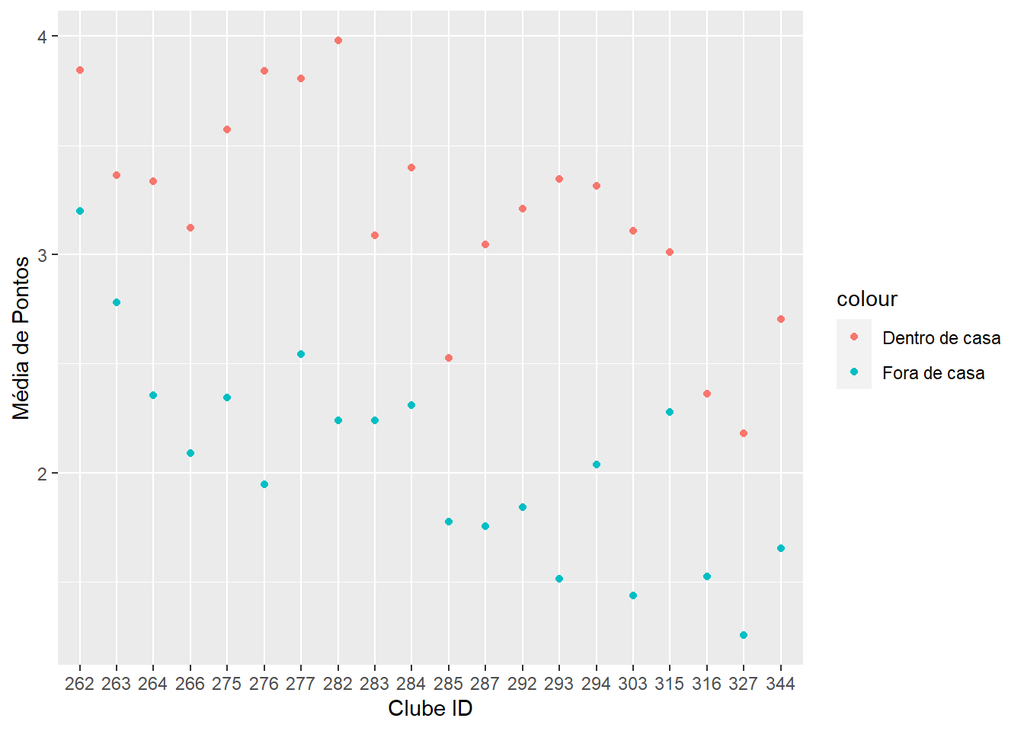

```r
analise_casa %>%
  group_by(clube_id) %>%
  ggplot() +
  geom_point(aes(as.factor(clube_id), pontos_casa, color = "Dentro de casa")) +
  geom_point(aes(as.factor(clube_id), pontos_visitante, color = "Fora de casa"))+
  xlab("Clube ID")+
  ylab("Média de Pontos")
```

Podemos ver que claramente os jogadores pontuam mais em média quando seus clubes estão jogando dentro de casa.

```r
partidas_dentro_de_casa %>%
  inner_join(partidas_fora_de_casa, c("clube_casa_id" = "clube_visitante_id"))%>%
  rename(clube_id = clube_casa_id ,
         pontos_casa = media_casa  ,
         pontos_visitante = media_visitante) %>%
  summarise(`Clubes com mais pontos em casa` = sum(pontos_casa>pontos_visitante), .groups = 'drop')%>%
  kbl() %>%
  kable_styling(full_width = F ,position = "left")
```

| Clubes com mais pontos em casa |
| --- |
| 20 |

Contando o número de clubes com mais pontos na média dentro de casa, temos o resultado que todos os 20 clubes pontuam mais com o fator casa.

```r
partidas_dentro_de_casa %>%
  inner_join(partidas_fora_de_casa, c("clube_casa_id" = "clube_visitante_id"))%>%
  rename(clube_id = clube_casa_id ,
         pontos_casa = media_casa  ,
         pontos_visitante = media_visitante) %>%
  summarise(`Soma de pontos em casa` = sum(pontos_casa),
            `Soma de pontos fora de casa` = sum(pontos_visitante), .groups = 'drop')%>%
  kbl() %>%
  kable_styling(full_width = F ,position = "left")
```

| Soma de pontos em casa | Soma de pontos fora de casa |
| --- | --- |
| 64.1491 | 41.13234 |

**Conclusão:**

Somando as médias de pontos dos clubes dentro e fora de casa também percebemos a diferença. Com isso, podemos inferir que no geral a pontuação diz bastante a respeito se o clube do jogador está jogando dentro de casa ou fora.

## 3.4 **Vale mais a pena escalar meias defensivos ou ofensivos?**

Pra isso, vamos analisar a correlação entre as pontuações médias ligadas a roubo de bola e ataque com as pontuações médias dos jogadores de meio. Vamos filtrar, além da posição “meia”, resultados apenas para jogadores que jogaram mais de 12 jogos.

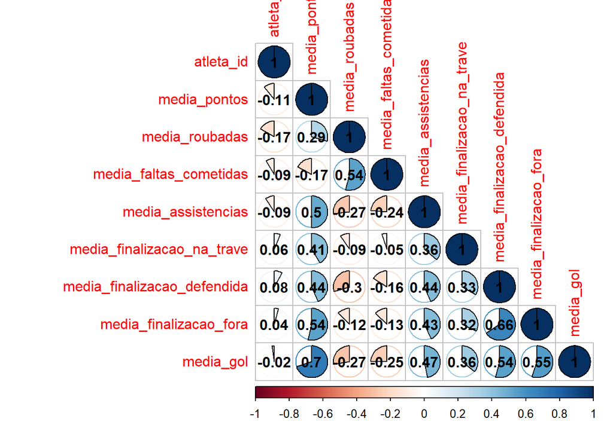

```r
meias_que_jogaram_constantemente <- scouts %>%
  left_join(atletas, c("atleta_id" = "id")) %>%
  filter(posicao_id == "meia") %>%
  group_by(atleta_id) %>%
  mutate(participacoes = sum(participou)) %>%
  filter(participacoes > 12)

scouts %>%
  left_join(atletas, c("atleta_id" = "id")) %>%
  filter(participou & posicao_id == "meia" &
           atleta_id %in% meias_que_jogaram_constantemente$atleta_id) %>%
  group_by(atleta_id)%>%
  summarise(media_pontos = mean(pontos_num),
            media_roubadas = mean(RB),
            media_faltas_cometidas = mean(FC),
            media_assistencias = mean(A),
            media_finalizacao_na_trave = mean(FT),
            media_finalizacao_defendida = mean(FD),
            media_finalizacao_fora = mean(FF),
            media_gol = mean(G), .groups = 'drop') %>%
  cor() %>%
  corrplot(type = "lower",method = "pie", addCoef.col = "black")
```

**Conclusão:**

Observando a coluna `pontos_num`, apesar de roubadas de bola (RB) ter uma boa correlação com a pontuação do jogador, os gols e finalizações tem uma correlação maior, assim, tornando preferível meios de campo que atacam mais mas não tornando descartável os meias que também defendem, dependendo da rodada.

**Bibliotecas utilizadas:** tidyverse, kableExtra e corrplot.